# R Notebook

# Initial data processing

We gather up all the data in a single dataframe so we can perform all of our cleaning and feature engineering simoultaniously on the train and test datasets.

```r
train = read.csv('Titanic/train.csv', na.strings = "")
test = read.csv('Titanic/test.csv', na.strings = "")
test$Survived = NA

data = rbind(train,test)

str(data)
```

```
## 'data.frame':    1309 obs. of  12 variables:
##  $ PassengerId: int  1 2 3 4 5 6 7 8 9 10 ...
##  $ Survived   : int  0 1 1 1 0 0 0 0 1 1 ...
##  $ Pclass     : int  3 1 3 1 3 3 1 3 3 2 ...
##  $ Name       : Factor w/ 1307 levels "Abbing, Mr. Anthony",..: 109 191 358 277 16 559 520 629 417 581 ...
##  $ Sex        : Factor w/ 2 levels "female","male": 2 1 1 1 2 2 2 2 1 1 ...
##  $ Age        : num  22 38 26 35 35 NA 54 2 27 14 ...
##  $ SibSp      : int  1 1 0 1 0 0 0 3 0 1 ...
##  $ Parch      : int  0 0 0 0 0 0 0 1 2 0 ...
##  $ Ticket     : Factor w/ 929 levels "110152","110413",..: 524 597 670 50 473 276 86 396 345 133 ...
##  $ Fare       : num  7.25 71.28 7.92 53.1 8.05 ...
##  $ Cabin      : Factor w/ 186 levels "A10","A14","A16",..: NA 82 NA 56 NA NA 130 NA NA NA ...
##  $ Embarked   : Factor w/ 3 levels "C","Q","S": 3 1 3 3 3 2 3 3 3 1 ...
```

Let’s clean up the data a bit.

```r
colnames(data) = c("id","survived","class","name","sex","age","siblings","other_family","ticket","fare","cabin","port")

data$survived = as.factor(data$survived)
data$class = as.factor(data$class)
data$cabin = as.character(data$cabin)
```

Let’s see how many NA’s we have in our data.

```r
for(col in names(data)){
  print(col)
  print(sum(!complete.cases(data[col])))
}
```

```
## [1] "id"
## [1] 0
## [1] "survived"
## [1] 418
## [1] "class"
## [1] 0
## [1] "name"
## [1] 0
## [1] "sex"
## [1] 0
## [1] "age"
## [1] 263
## [1] "siblings"
## [1] 0
## [1] "other_family"
## [1] 0
## [1] "ticket"
## [1] 0
## [1] "fare"
## [1] 1
## [1] "cabin"
## [1] 1014
## [1] "port"
## [1] 2
```

```r
data$cabin[is.na(data$cabin)] = ""
data$fare[is.na(data$fare)] = mean(data$fare, na.rm = T)
data$port[is.na(data$port)] = names(which.max(table(data$port)))
data$age[is.na(data$age)] = predict(lm(age ~ other_family + sex + siblings + other_family , data, na.action = na.omit),data)[is.na(data$age)]
```

Make sure we have no NA’s (except survived)

```r
sum(!complete.cases(data[,-2]))
```

```
## [1] 0
```

Great, now let’s do some feature engineeing: 1. We get the familiy size 2. Bin rows according to age range 3. Extract some useful information from the name 4. Extract the cabin count and cabin first letter 5. Scaling age and fare

```r
data$familiy = data$siblings + data$other_family + 1

data$child = data$age < 15
data$adulecent = 15 <= data$age && data$age < 30
data$adult = 30 <= data$age && data$age < 50
data$old = 50 <= data$age

data$honor = as.factor(sub(' ', '', sapply(as.character(data$name), FUN=function(x) strsplit(x, split='[,.]')[[1]][2])))

data$cabin_count = sapply(strsplit(data$cabin, "\\s+"), length)

data$cabin_letter = as.factor(sapply(data$cabin, function(x) {substr(x,1,1)}))

data$fare = scale(data$fare)
data$age = scale(data$age)

str(data)
```

```
## 'data.frame':    1309 obs. of  20 variables:
##  $ id          : int  1 2 3 4 5 6 7 8 9 10 ...
##  $ survived    : Factor w/ 2 levels "0","1": 1 2 2 2 1 1 1 1 2 2 ...
##  $ class       : Factor w/ 3 levels "1","2","3": 3 1 3 1 3 3 1 3 3 2 ...
##  $ name        : Factor w/ 1307 levels "Abbing, Mr. Anthony",..: 109 191 358 277 16 559 520 629 417 581 ...
##  $ sex         : Factor w/ 2 levels "female","male": 2 1 1 1 2 2 2 2 1 1 ...
##  $ age         : num [1:1309, 1] -0.606 0.614 -0.301 0.385 0.385 ...
##   ..- attr(*, "scaled:center")= num 29.9
##   ..- attr(*, "scaled:scale")= num 13.1
##  $ siblings    : int  1 1 0 1 0 0 0 3 0 1 ...
##  $ other_family: int  0 0 0 0 0 0 0 1 2 0 ...
##  $ ticket      : Factor w/ 929 levels "110152","110413",..: 524 597 670 50 473 276 86 396 345 133 ...
##  $ fare        : num [1:1309, 1] -0.503 0.734 -0.49 0.383 -0.488 ...
##   ..- attr(*, "scaled:center")= num 33.3
##   ..- attr(*, "scaled:scale")= num 51.7
##  $ cabin       : chr  "" "C85" "" "C123" ...
##  $ port        : Factor w/ 3 levels "C","Q","S": 3 1 3 3 3 2 3 3 3 1 ...
##  $ familiy     : num  2 2 1 2 1 1 1 5 3 2 ...
##  $ child       : logi  FALSE FALSE FALSE FALSE FALSE FALSE ...
##  $ adulecent   : logi  TRUE TRUE TRUE TRUE TRUE TRUE ...
##  $ adult       : logi  FALSE FALSE FALSE FALSE FALSE FALSE ...
##  $ old         : logi  FALSE FALSE FALSE FALSE FALSE FALSE ...
##  $ honor       : Factor w/ 18 levels "Capt","Col","Don",..: 13 14 10 14 13 13 13 9 14 14 ...
##  $ cabin_count : int  0 1 0 1 0 0 1 0 0 0 ...
##  $ cabin_letter: Factor w/ 9 levels "","A","B","C",..: 1 4 1 4 1 1 6 1 1 1 ...
```

Let’s get rid of unnesesery data.

```r
data = data[, -which(names(data) %in% c("name","cabin","ticket","siblings","other_family"))]
attach(data)
train = data[!is.na(survived),]
test = data[is.na(survived),]
str(data)
```

```
## 'data.frame':    1309 obs. of  15 variables:
##  $ id          : int  1 2 3 4 5 6 7 8 9 10 ...
##  $ survived    : Factor w/ 2 levels "0","1": 1 2 2 2 1 1 1 1 2 2 ...
##  $ class       : Factor w/ 3 levels "1","2","3": 3 1 3 1 3 3 1 3 3 2 ...
##  $ sex         : Factor w/ 2 levels "female","male": 2 1 1 1 2 2 2 2 1 1 ...
##  $ age         : num [1:1309, 1] -0.606 0.614 -0.301 0.385 0.385 ...
##   ..- attr(*, "scaled:center")= num 29.9
##   ..- attr(*, "scaled:scale")= num 13.1
##  $ fare        : num [1:1309, 1] -0.503 0.734 -0.49 0.383 -0.488 ...
##   ..- attr(*, "scaled:center")= num 33.3
##   ..- attr(*, "scaled:scale")= num 51.7
##  $ port        : Factor w/ 3 levels "C","Q","S": 3 1 3 3 3 2 3 3 3 1 ...
##  $ familiy     : num  2 2 1 2 1 1 1 5 3 2 ...
##  $ child       : logi  FALSE FALSE FALSE FALSE FALSE FALSE ...
##  $ adulecent   : logi  TRUE TRUE TRUE TRUE TRUE TRUE ...
##  $ adult       : logi  FALSE FALSE FALSE FALSE FALSE FALSE ...
##  $ old         : logi  FALSE FALSE FALSE FALSE FALSE FALSE ...
##  $ honor       : Factor w/ 18 levels "Capt","Col","Don",..: 13 14 10 14 13 13 13 9 14 14 ...
##  $ cabin_count : int  0 1 0 1 0 0 1 0 0 0 ...
##  $ cabin_letter: Factor w/ 9 levels "","A","B","C",..: 1 4 1 4 1 1 6 1 1 1 ...
```

# Analysis

Let’s analyze the data a bit.

```r
table(survived,sex)
```

```
##         sex
## survived female male
##        0     81  468
##        1    233  109
```

```r
table(survived,port)
```

```
##         port
## survived   C   Q   S
##        0  75  47 427
##        1  93  30 219
```

```r
table(survived,class)
```

```
##         class
## survived   1   2   3
##        0  80  97 372
##        1 136  87 119
```

```r
table(survived,child)
```

```
##         child
## survived FALSE TRUE
##        0   509   40
##        1   297   45
```

```r
table(survived,cabin_count)
```

```
##         cabin_count
## survived   0   1   2   3   4
##        0 481  58   7   3   0
##        1 206 122   9   3   2
```

```r
table(survived,cabin_letter)
```

```
##         cabin_letter
## survived       A   B   C   D   E   F   G   T
##        0 481   8  12  24   8   8   5   2   1
##        1 206   7  35  35  25  24   8   2   0
```

# Split

Those all seem to be very important parameters, let’s split the training data into validation and examples!

```r
ratio = 0.75
set.seed(1)
indecies = sample(1:nrow(train),nrow(train)*ratio)
examples = train[indecies,]
validation = train[-indecies,]
```

# Simplest Model

Let’s try to think of the simplest model for our problem. As we have seen, the most important paramenters for determening the survival are: sex and class. Let’s use those to predict who survives using a simple formula(no learning). `survived ~ sex = female /\ class = 1`

## Validation

We get a decent accuracy on the train data (better than chance).

```r
library(caret)
values = factor(train$sex == "female" & train$class == "1", labels=c("0","1"))
confusionMatrix(values, train$survived)
```

```
## Confusion Matrix and Statistics
##
##           Reference
## Prediction   0   1
##          0 546 251
##          1   3  91
##
##                Accuracy : 0.7149
##                  95% CI : (0.684, 0.7444)
##     No Information Rate : 0.6162
##     P-Value [Acc > NIR] : 3.912e-10
##
##                   Kappa : 0.3019
##  Mcnemar's Test P-Value : < 2.2e-16
##
##             Sensitivity : 0.9945
##             Specificity : 0.2661
##          Pos Pred Value : 0.6851
##          Neg Pred Value : 0.9681
##              Prevalence : 0.6162
##          Detection Rate : 0.6128
##    Detection Prevalence : 0.8945
##       Balanced Accuracy : 0.6303
##
##        'Positive' Class : 0
##
```

## Prediction

Let’s do the predictions and see how we did. (update: we got 0.71291 accuracy)

```r
predictions = factor(test$sex == "female" & test$class == "1", labels = c("0","1"))
test$simple.model = predictions
write.table(subset(test, select = c("id","simple.model")),
            row.names=FALSE,
            col.names = c("PassengerId","Survived"),
            "Predictions/simple.csv",
            quote = F,
            sep = ",")
```

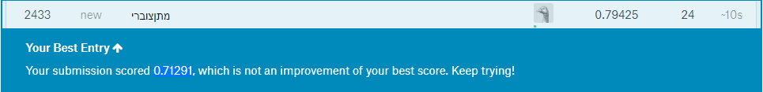

Proof of 0.71291 accuracy!

# Decision Tree (rpart)

## Training

Let’s build a decision tree

```r
library(rpart)
dt.model = rpart(survived ~ ., data, method = 'class')
dt.model
```

```
## n=891 (418 observations deleted due to missingness)
##
## node), split, n, loss, yval, (yprob)
##       * denotes terminal node
##
##  1) root 891 342 0 (0.61616162 0.38383838)
##    2) honor=Capt,Don,Dr,Jonkheer,Mr,Rev 533  84 0 (0.84240150 0.15759850) *
##    3) honor=Col,Lady,Major,Master,Miss,Mlle,Mme,Mrs,Ms,Sir,the Countess 358 100 1 (0.27932961 0.72067039)
##      6) class=3 172  83 0 (0.51744186 0.48255814)
##       12) familiy>=4.5 45   4 0 (0.91111111 0.08888889) *
##       13) familiy< 4.5 127  48 1 (0.37795276 0.62204724) *
##      7) class=1,2 186  11 1 (0.05913978 0.94086022) *
```

## Validation

That looks like a good start, we get a ~83% accuracy on the validation set with a CI of a minimum ~77% accuracy.

```r
library(caret)
values = predict(dt.model, validation[,-2], type = 'class')
confusionMatrix(validation[,2],values)
```

```
## Confusion Matrix and Statistics
##
##           Reference
## Prediction   0   1
##          0 120  15
##          1  23  65
##
##                Accuracy : 0.8296
##                  95% CI : (0.7737, 0.8765)
##     No Information Rate : 0.6413
##     P-Value [Acc > NIR] : 4.363e-10
##
##                   Kappa : 0.6376
##  Mcnemar's Test P-Value : 0.2561
##
##             Sensitivity : 0.8392
##             Specificity : 0.8125
##          Pos Pred Value : 0.8889
##          Neg Pred Value : 0.7386
##              Prevalence : 0.6413
##          Detection Rate : 0.5381
##    Detection Prevalence : 0.6054
##       Balanced Accuracy : 0.8258
##
##        'Positive' Class : 0
##
```

## Prediction

Let’s predict on the test data and see how we did on kaggle. (update: We got 0.78947, 3119th place)

```r
predictions = predict(dt.model, test[,-2], type = 'class')
test$dt.model = predictions
write.table(subset(test, select = c("id","dt.model")), row.names=FALSE, col.names = c("PassengerId","Survived"), "Predictions/dt.csv", quote = F, sep = ",")
```

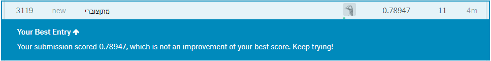

Proof of 3119 place!

# Ensemble (Weighted Subspace Random Forests)

## Training

Let’s try a random forest ensemble.

```r
library(caret)
en.model = train(survived ~ .,data=examples, method="wsrf",
                trControl=trainControl(method="cv",number=5))
```

```
## wsrf: An R Package for Scalable Weighted Subspace Random Forests.
```

```
## Version 1.7.17
```

```
## Use C++ standard thread library for parallel computing
```

```r
en.model
```

```
## Weighted Subspace Random Forest
##
## 668 samples
##  14 predictor
##   2 classes: '0', '1'
##
## No pre-processing
## Resampling: Cross-Validated (5 fold)
## Summary of sample sizes: 535, 534, 534, 534, 535
## Resampling results across tuning parameters:
##
##   mtry  Accuracy   Kappa
##    2    0.8129166  0.5923279
##   20    0.8069128  0.5798656
##   39    0.8084278  0.5830066
##
## Accuracy was used to select the optimal model using  the largest value.
## The final value used for the model was mtry = 2.
```

## Validation

```r
library(caret)
values = predict(en.model, validation[,-2], type = 'raw')
confusionMatrix(validation[,2],values)
```

```
## Confusion Matrix and Statistics
##
##           Reference
## Prediction   0   1
##          0 125  10
##          1  27  61
##
##                Accuracy : 0.8341
##                  95% CI : (0.7786, 0.8804)
##     No Information Rate : 0.6816
##     P-Value [Acc > NIR] : 1.795e-07
##
##                   Kappa : 0.6407
##  Mcnemar's Test P-Value : 0.008529
##
##             Sensitivity : 0.8224
##             Specificity : 0.8592
##          Pos Pred Value : 0.9259
##          Neg Pred Value : 0.6932
##              Prevalence : 0.6816
##          Detection Rate : 0.5605
##    Detection Prevalence : 0.6054
##       Balanced Accuracy : 0.8408
##
##        'Positive' Class : 0
##
```

## Prediction

Let’s predict on the test data and see how we did on kaggle. (update: We got 0.79425, 2439th place)

```r
predictions = predict(en.model, test[,-2], type = 'raw')
test$en.model = predictions
write.table(subset(test, select = c("id","en.model")), row.names=FALSE,col.names = c("PassengerId","Survived"), "Predictions/en.csv", quote = F, sep = ",")
```

[figure not shown]

Proof of 2439 place!